# BOO 2025 - Example Analysis

Script 6: Functional enrichment

Bärbel Smit

2025-05-26

> In this script, you will biologically interpret your differentially expressed genes.

# 1 Setup

## 1.1 Clean

As before, we perform several setup steps at the start of the script to ensure our work is reproducible and clear.

**Exercise 1: Download the R markdown template, clean your environment, and set the folhighing variables:**

- `root_dir` - project folder
- `low_store` - location of DEG results for the low toxicity compound
- `high_store` - location of DEG results for the high toxicity compound

```r
# Clean environment
rm(list=ls())

# set variables
root_dir <- "C:/Users/Bärbel Smit/Universiteit Leiden/BOO 2025 - BOO CDS Giulia team - BOO CDS Giulia team/Students/Bärbel/project/barbelsmit_BOO/"


low_store <- "DEG/DEGres_low.Rdata"
high_store <- "DEG/DEGres_high.Rdata"
```

## 1.2 Packages

In this script, we introduce a new package: `enrichR`, a package for gene set enrichment analysis that identifies biological pathways, gene ontology terms, and other functional annotations significantly associated with a given list of genes.

**Exercise 2: Load `enrichR` and `tidyverse` into your R environment:**

```r
#load packages
library(tidyverse)
library(enrichR)
```

## 1.3 Load data

**Exercise 3: Load the DEG results R environment:**

```r
# load data
load(paste0(root_dir, high_store))
load(paste0(root_dir, low_store))
```

# 2 ORA

## 2.1 Databases

When performing any type of gene set analysis, you need to specify the gene sets of interest. This is one of the pitfalls but also benefits of this type of analysis.

**Exercise 4: Use `listEnrichrDbs()` and look at the gene set databases available. Select a few of interest and describe them:**

**Hint**

Sometimes a specific database has different version for different years. Try to select the most recent ones using `grepl`.

```r
# filter the available Enrichr databases to those that include "202" in their libraryName, to find datasets from 2020 till now
listEnrichrDbs() %>%
  filter(grepl("202", libraryName))
```

| geneCoverage | genesPerTerm | libraryName | link | numTerms | appyter | categoryId |
| --- | --- | --- | --- | --- | --- | --- |
| 11851 | 586 | CCLE_Proteomics_2020 | https://portals.broadinstitute.org/ccle | 378 | 7094b097ae2301a1d6a5bd856a193b084cca993d | 5 |
| 8189 | 421 | ProteomicsDB_2020 | https://www.proteomicsdb.org/ | 913 | 8c87c8346167bac2ba68195a32458aba9b1acfd1 | 5 |
| 5605 | 39 | Virus-Host_PPI_P-HIPSTer_2020 | http://phipster.org/ | 6715 | a592eed13e8e9496aedbab63003b965574e46a65 | 2 |
| 4383 | 146 | MSigDB_Hallmark_2020 | https://www.gsea-msigdb.org/gsea/msigdb/collections.jsp | 50 | 6952efda94663d4bd8db09bf6eeb4e67d21ef58c | 2 |
| 54974 | 483 | Enrichr_Users_Contributed_Lists_2020 | https://maayanlab.cloud/Enrichr | 1482 | 8dc362703b38b30ac3b68b6401a9b20a58e7d3ef | 6 |
| 12118 | 448 | TG_GATES_2020 | https://toxico.nibiohn.go.jp/english/ | 1190 | 9e32560437b11b4628b00ccf3d584360f7f7daee | 4 |
| 12361 | 124 | Allen_Brain_Atlas_10x_scRNA_2021 | https://portal.brain-map.org/ | 766 | 46f8235cb585829331799a71aec3f7c082170219 | 5 |
| 9763 | 139 | Descartes_Cell_Types_and_Tissue_2021 | https://descartes.brotmanbaty.org/bbi/human-gene-expression-during-development/ | 172 |  | 5 |
| 8078 | 102 | KEGG_2021_Human | https://www.kegg.jp/ | 320 |  | 2 |
| 7173 | 43 | WikiPathway_2021_Human | https://www.wikipathways.org/ | 622 |  | 7 |

[output cut: 51 more lines]

- `MSigDB_Hallmark_2020`: gene sets curated by the Broad Institute from the Molecular Signatures Database (MSigDB), repesenting coherent biological states or processes aimed to reduce redundancy in gene set databases.
- `TG_GATES_2020`: derived from the Toxicogenomics Project-Genomics Assisted Toxicity Evaluation System (TG-GATEs), this database links gene expression changes to specific chemical exposures in rodent and human hepatocytes, providing mechanistic insights into toxicity and drug safety.
- `GO_Biological_Process_2025`, `GO_Cellular_Component_2025`, and `GO_Molecular_Function_2025` are part of the Gene Ontology (GO) Consortium, and capture structured biological processes (e.g. inflammatory response), subcellular locations (e.g. mitochondrial matrix), and molecular activities (e.g. ATP binding), respectively.
- `WikiPathways_2024_Human` is an open-source, community-curated collection of human biological pathways hosted by the WikiPathways project, aimed at enhancing transparency and collaboration in pathway annotation across a range of processes and diseases.
- `Reactome_Pathways_2024` is a peer-reviewed and manually curated database of human pathways developed by the Reactome Consortium, emphasizing detailed molecular interactions and regulatory mechanisms across signalling, metabolism, and disease.
- `KEGG_2021_Human` is developed by the Kyoto Encyclopedia of Genes and Genomes (KEGG) and contains human pathway maps integrating genomic, chemical, and functional data to support systems-level understanding of cellular and organismal functions.

## 2.2 DEG List

In order to run ORA you need a list of genes of interest (your DEGs).

**Exercise 5: Make a DEG list for each of the two compounds. How many DEGs do you have for each?**

**Hint**

If you compound shows a dose response, you may want to select genes at a particular concentration of interest.

```r
# Get unique significant DEGs from the high tox group
deg_high <- unique((res_high %>%
               filter(sig == T))$gene_symbol)

# Get unique significant DEGs from the low tox group
deg_low <- unique((res_low %>%
               filter(sig == T))$gene_symbol)
```

There are 351 DEGs for the high toxicity compound (Theophylline) and 3333 for the low toxicity one (Metformin).

## 2.3 Enrichr

The `enrichr` function performs over-representation analysis (ORA) using a list of genes in each of the databases specified by the `databases` argument, returning a list.

**Exercise 6: Run `enrichr` using the selected databases and inspect the output for each compound. Are there any pathways you expected?:**

**Hint**

You can use `bind_rows()` to convert lists into data frames and make inspecting the output easier.

```r
# Run enrichment analysis using the latest versions of Gene Ontology (GO), Reactome, and KEGG.
ora_high <- enrichr(deg_high,
                       c("GO_Biological_Process_2025",
                         "GO_Molecular_Function_2025",
                         "Reactome_Pathways_2024",
                         "KEGG_2021_Human"))
```

```
## Uploading data to Enrichr... Done.
##   Querying GO_Biological_Process_2025... Done.
##   Querying GO_Molecular_Function_2025... Done.
##   Querying Reactome_Pathways_2024... Done.
##   Querying KEGG_2021_Human... Done.
## Parsing results... Done.
```

```r
# Combine the multiple enrichment result data frames into a single unified table
ora_high <- bind_rows(ora_high)

# Filter for statistically significant pathways (adjusted p-value ≤ 0.05)
ora_high %>% filter(Adjusted.P.value <= 0.05)
```

| Term | Overlap | P.value | Adjusted.P.value | Old.P.value | Old.Adjusted.P.value | Odds.Ratio | Combined.Score | Genes |
| --- | --- | --- | --- | --- | --- | --- | --- | --- |
| Translation (GO:0006412) | 24/232 | 3.382393e-12 | 6.456988e-09 | 0 | 0 | 6.859915 | 181.18709 | RPL21;RPS8;VTA1;RPL23A;RPL8;EEF2;RPL9;MRPL57;GSPT1;MRPL21;DARS1;WARS1;RPS15;EEF1A1;RPS17;MRPS9;RPS29;MTG1;RPL36;RPS3;RPS20;RPS11;AURKAIP1;RPS12 |
| Macromolecule Biosynthetic Process (GO:0009059) | 20/189 | 1.488091e-10 | 1.420383e-07 | 0 | 0 | 6.964729 | 157.60038 | RPL21;RPS8;RPL23A;RPL8;EEF2;RPL9;GSPT1;DARS1;WARS1;RPS15;EEF1A1;RPS17;RPS29;RPL36;RPS3;RPS20;RPS11;EIF4G2;RPS12;TGM2 |
| Cytoplasmic Translation (GO:0002181) | 15/101 | 2.601472e-10 | 1.655403e-07 | 0 | 0 | 10.155212 | 224.12322 | RPL21;RPS8;VTA1;RPL23A;RPL8;RPL9;RPS15;RPS17;RPS29;EIF3I;RPL36;RPS3;RPS20;RPS11;RPS12 |
| Gene Expression (GO:0010467) | 25/381 | 1.826759e-08 | 8.718209e-06 | 0 | 0 | 4.155968 | 74.05160 | RPL8;RPL9;GSPT1;SMG5;RPS15;RPS17;RPL36;RPS3;RPS11;RBM5;RPS12;TGM2;RPL21;RPS8;TESC;RPL23A;DARS1;WARS1;THAP1;EEF1A1;DDX39A;RPS29;MPHOSPH10;RPS20;AURKAIP1 |
| Proton Motive Force-Driven Mitochondrial ATP Synthesis (GO:0042776) | 9/52 | 2.697828e-07 | 1.030031e-04 | 0 | 0 | 11.998776 | 181.48927 | ATP5PF;ATP5PD;NDUFA11;NDUFA3;ATP5PO;NDUFB1;NDUFC1;ATP5F1D;ATP5MF |
| Proton Motive Force-Driven ATP Synthesis (GO:0015986) | 9/59 | 8.271094e-07 | 2.613098e-04 | 0 | 0 | 10.315263 | 144.46865 | ATP5PF;ATP5PD;NDUFA11;NDUFA3;ATP5PO;NDUFB1;NDUFC1;ATP5F1D;ATP5MF |
| Oxidative Phosphorylation (GO:0006119) | 9/60 | 9.581814e-07 | 2.613098e-04 | 0 | 0 | 10.112487 | 140.14116 | ATP5PF;ATP5PD;NDUFA11;NDUFA3;ATP5PO;NDUFB1;NDUFC1;ATP5F1D;ATP5MF |
| Ribonucleoprotein Complex Biogenesis (GO:0022613) | 11/120 | 8.775821e-06 | 1.991549e-03 | 0 | 0 | 5.799784 | 67.52985 | RPS15;RCL1;RPS17;WDR36;RPS8;GTF3A;RRS1;NOL7;MPHOSPH10;RPS11;RPS12 |
| Protein Transport (GO:0015031) | 18/308 | 9.389177e-06 | 1.991549e-03 | 0 | 0 | 3.608388 | 41.77053 | TMED10;FGG;AFM;AP2A1;MCOLN1;STX10;EHD1;RAB32;RAB10;KRT18;CTTN;CANX;LAMP2;TOM1;RAB18;RAB17;APOB;YWHAH |
| Ribosomal Small Subunit Biogenesis (GO:0042274) | 9/85 | 1.816298e-05 | 3.467314e-03 | 0 | 0 | 6.777355 | 73.98245 | RPS15;RCL1;RPS17;WDR36;RPS8;NOL7;MPHOSPH10;RPS11;RPS12 |

[output cut: 90 more lines]

There are 100 enriched terms in the DEGs from the high toxicity compound (theophylline).

*`translation`* `Cytoplasmic Translation` *`Ribosomal Small Subunit Biogenesis`* `Ribonucleoprotein Complex Biogenesis` These are all related to protein synthesis, and theophylline has known effects on cAMP levels, via inhibition of phosphodiesterases, and modulation of translation through signaling pathways like mTOR and PKA, especially at high concentrations.

*`gene expression` and `Macromolecule Biosynthetic Process` are broad pathways but still consistent with increased transcription or translation, which might result from stress responses or metabolic adaptation after drug exposure.

*`Proton Motive Force-Driven ATP Synthesis`, `Proton Motive Force-Driven Mitochondrial ATP Synthesis` and `Oxidative Phosphorylation` point to mitochondrial activity and energy metabolism (involving ATP). Theophylline metabolism occurs in the liver via CYP enzymes, which rely on mitochondrial support. It can induce some mitochondrial stress or increase energy demand, possibly triggering changes in oxidative phosphorylation.

```r
# Run enrichment analysis using the latest versions of Gene Ontology (GO), Reactome, and KEGG.
ora_low <- enrichr(deg_low,
                       c("GO_Biological_Process_2025",
                         "GO_Molecular_Function_2025",
                         "Reactome_Pathways_2024",
                         "KEGG_2021_Human"))
```

```
## Uploading data to Enrichr... Done.
##   Querying GO_Biological_Process_2025... Done.
##   Querying GO_Molecular_Function_2025... Done.
##   Querying Reactome_Pathways_2024... Done.
##   Querying KEGG_2021_Human... Done.
## Parsing results... Done.
```

```r
# Combine the multiple enrichment result data frames into a single unified table
ora_low <- bind_rows(ora_low)

# Filter for statistically significant pathways (adjusted p-value ≤ 0.05)
ora_low %>% filter(Adjusted.P.value <= 0.05)
```

| Term | Overlap | P.value | Adjusted.P.value | Old.P.value | Old.Adjusted.P.value | Odds.Ratio | Combined.Score | Genes |
| --- | --- | --- | --- | --- | --- | --- | --- | --- |
| Ribosome Biogenesis (GO:0042254) | 87/161 | 1.863225e-27 | 8.922984e-24 | 0 | 0 | 6.009854 | 369.891429 | LTV1;NVL;PAK1IP1;WDR3;SPPL2A;PWP2;WDR43;RPL7;RRP9;RPS15;RPS4X;RPS14;RPS17;RPS16;XPO1;RPS19;NOB1;RIOK1;GLUL;EIF2A;PELP1;NOM1;WDR36;AFG2A;RPS8;RPS5;RPS6;GTF3A;WDR74;DNTTIP2;DDX54;IMP4;GTPBP4;EBNA1BP2;DK… |
| rRNA Processing (GO:0006364) | 66/110 | 1.200675e-24 | 2.875017e-21 | 0 | 0 | 7.632231 | 420.376880 | NVL;WDR3;SPPL2A;RPL7;RRP9;RPS15;RPS14;RPL7A;TRMT112;RPS17;RPS16;RPS19;NOB1;RIOK1;RRP15;PELP1;WDR36;REXO1;RPS6;WDR74;DDX54;IMP4;EBNA1BP2;DKC1;MRTO4;XRN2;RPL27;SRFBP1;RPL26;PRKDC;NOP2;MAK16;RPL11;NOL7;N… |
| Translation (GO:0006412) | 102/232 | 9.237514e-23 | 1.474615e-19 | 0 | 0 | 4.015842 | 203.748486 | RPL4;RPL3;RPL31;RPL8;APEH;RPL9;RPL6;RPL7;RPS15;RPS14;RPS17;RPS16;RPL18A;RPS19;RPL36;RPL35;RPL38;HEMK1;RPL21;RPS8;RPL23;RPS5;RPS6;FTSJ1;EEF1A1;LARS1;EEF1A2;RPL27;RPL26;RPL28;MRPL18;EIF5A2;MRPL19;MRPL14… |
| Ribonucleoprotein Complex Biogenesis (GO:0022613) | 65/120 | 6.149164e-21 | 7.362087e-18 | 0 | 0 | 6.007455 | 279.574775 | LTV1;NVL;PAK1IP1;WDR3;SPPL2A;PWP2;WDR43;RPL7;RRP9;RPS15;RPS4X;RPS14;RPS17;RPS16;XPO1;RPS19;RPL38;RIOK1;GLUL;NOM1;WDR36;AFG2A;RPS8;RPS5;RPS6;GTF3A;WDR74;DNTTIP2;IMP4;GTPBP4;EBNA1BP2;MRTO4;NAF1;RPL26;RP… |
| rRNA Metabolic Process (GO:0016072) | 55/98 | 6.919221e-19 | 6.627230e-16 | 0 | 0 | 6.486655 | 271.238279 | NVL;SPPL2A;RPL7;RRP9;RPS15;RPS17;RPS16;RPS19;NOB1;MYC;PELP1;WDR36;RPS6;GTF3A;WDR74;DDX54;IMP4;SIRT7;EBNA1BP2;DKC1;MRTO4;XRN2;RPL27;RPL26;GTF3C1;NOP2;RPL11;NOL8;NOC4L;MRM1;MRM3;NOL6;RRP7A;MYG1;EXOSC5;E… |
| Gene Expression (GO:0010467) | 130/381 | 4.495887e-17 | 3.588467e-14 | 0 | 0 | 2.654484 | 99.916840 | RPL4;ISCA1;RPL3;RPL31;FMR1;HNRNPU;ADARB1;RPL8;PWP1;RPL9;CISD3;RPL6;RPL7;GLE1;RPS15;CHCHD4;RPS14;RPS17;RPS16;RPL18A;RPS19;RPL36;RPL35;ENPP1;RPL38;CIAO2B;TGM2;RPL21;RPS8;RPL23;RPS5;RPS6;DNTTIP2;THOC2;EE… |
| Cytoplasmic Translation (GO:0002181) | 53/101 | 1.540101e-16 | 1.053649e-13 | 0 | 0 | 5.594557 | 203.695085 | EIF4A2;RPL4;EIF4A1;RPL3;RPL31;RPL8;RPL9;RPL6;RPL7;RPS15;RPS4X;RPS14;RPL7A;RPS17;RPS16;RPL18A;RPS19;RPL36;RACK1;RPL35;RPL38;RPL21;RPS8;RPL23;RPS5;RPS6;RPL13A;FTSJ1;SARS1;RPL27;RPL26;RPL28;RPL12;RPL11;R… |
| Macromolecule Biosynthetic Process (GO:0009059) | 78/189 | 7.790303e-16 | 4.663470e-13 | 0 | 0 | 3.574177 | 124.340189 | RPL4;MRPS17;HBS1L;MRPS15;RPL3;ALAS1;MRPS16;RPL31;MRPL37;RPL8;RPL9;RPL6;MRPL32;RPL7;RPS15;RPS4X;RPS14;MRPL3;RPL7A;RPS17;RPS16;RPL18A;RPS19;RPL36;ENPP1;RPL35;RPL38;MRPL9;TGM2;RPL21;RPS8;RPL23;RPS5;RPS6;… |
| protein-RNA Complex Assembly (GO:0022618) | 61/138 | 2.608416e-14 | 1.387967e-11 | 0 | 0 | 4.016726 | 125.632938 | NVL;ADAR;PWP2;PRPF19;RPS15;COIL;RPS14;RPS19;RPL38;SNRPD3;EIF2S3B;PRMT5;RPS5;PRP4K;MRPS7;DDX39B;GEMIN4;GEMIN5;GEMIN6;SNRPE;SRFBP1;NAF1;SNRPF;SRSF5;SNRPC;SRSF6;SRSF9;TSSC4;PRKDC;NOP2;RPL11;SRSF1;NOL3;RR… |
| RNA Processing (GO:0006396) | 101/291 | 4.218459e-14 | 2.020220e-11 | 0 | 0 | 2.710033 | 83.460128 | PDCD7;SPPL2A;HNRNPU;ADARB1;VIRMA;RPL7;RRP9;THG1L;RPS15;RPS17;RPS16;RPS19;SNRPD3;MTPAP;CMTR1;RPS6;WDR74;DNTTIP2;IMP4;EBNA1BP2;DDX39B;DKC1;XRN2;MRTO4;RPL27;SRSF4;RPL26;SNRPF;SRSF5;SRSF9;NOP2;RRP7A;MYG1;… |

[output cut: 587 more lines]

There are 597 enriched terms in the DEGs from the low toxicity compound (metformin).

## 2.4 Plots

## 2.5 Bar plots

Using `geom_col`, we can visualize the results for each of the compounds.

**Exercise 7: Take a look at the top enriched terms for each compound:**

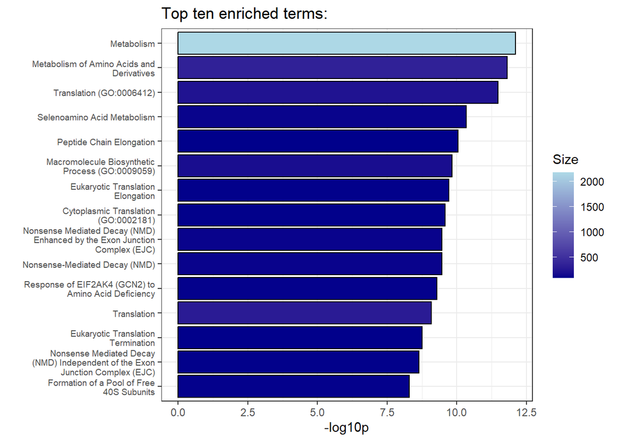

```r
ora_high %>%
  arrange(Adjusted.P.value, P.value) %>%
  head(15) %>%
  mutate(log10p = -log10(P.value)) %>%
  separate(Overlap,
           sep="/",
           into=c("Genes_found", "Size"),
           remove=F) %>%
  mutate(Size = as.numeric(Size)) %>%
  ggplot(aes(y=reorder(Term, log10p))) +
  geom_col(aes(x=log10p, fill = Size),
           color='black') +
  scale_fill_gradient(
    low = "#00008b",   # Light blue
    high = "#add8e6"   # Dark blue
  ) +
  ylab('') + xlab('-log10p') + ggtitle("Top ten enriched terms: ") +
  scale_y_discrete(labels = function(x) str_wrap(x, width = 30)) +
  theme_bw() +
  theme(axis.text.y = element_text(size=7))
```

```r
# Show table of top 15 pathways
ora_high %>%
  arrange(Adjusted.P.value, P.value) %>%
  head(15) %>%
  mutate(log10p = -log10(P.value)) %>%
  separate(Overlap,
           sep="/",
           into=c("Genes_found", "Size"),
           remove=F) %>%
  mutate(Size = as.numeric(Size))
```

|  | Term | Overlap | Genes_found | Size | P.value | Adjusted.P.value | Old.P.value | Old.Adjusted.P.value | Odds.Ratio | Combined.Score | Genes | log10p |
| --- | --- | --- | --- | --- | --- | --- | --- | --- | --- | --- | --- | --- |
| 1 | Metabolism | 85/2181 | 85 | 2181 | 7.846959e-13 | 8.071324e-10 | 0 | 0 | 2.676069 | 74.59137 | CDA;NDUFA11;ADPGK;TAT;QPRT;ACSM2A;MSMO1;RPL8;CSAD;RPL9;FTCD;RPS15;PSMD6;RPS17;GLIPR1;KYNU;SUMO2;RPL36;TNFAIP8L1;HMGCS2;RPS11;RPS12;ABCC3;SDS;RPL21;UGT1A1;GPX4;RPS8;CTPS1;APOA4;NDUFC1;MED6;DARS1;PISD;P… | 12.105299 |
| 2 | Metabolism of Amino Acids and Derivatives | 30/358 | 30 | 358 | 1.546231e-12 | 8.071324e-10 | 0 | 0 | 5.505186 | 149.71463 | NNMT;HAAO;TAT;ODC1;RPL8;CSAD;RPL9;FTCD;RPS15;PSMD6;RPS17;KYNU;AFMID;RPL36;RPS3;PCBD1;RPS11;RPS12;SDS;RPL21;RPS8;TXNRD1;RPL23A;DARS1;AGMAT;RPS29;PSAT1;CTH;KYAT1;RPS20 | 11.810726 |
| 3 | Translation (GO:0006412) | 24/232 | 24 | 232 | 3.382393e-12 | 6.456988e-09 | 0 | 0 | 6.859915 | 181.18709 | RPL21;RPS8;VTA1;RPL23A;RPL8;EEF2;RPL9;MRPL57;GSPT1;MRPL21;DARS1;WARS1;RPS15;EEF1A1;RPS17;MRPS9;RPS29;MTG1;RPL36;RPS3;RPS20;RPS11;AURKAIP1;RPS12 | 11.470776 |
| 4 | Selenoamino Acid Metabolism | 17/122 | 17 | 122 | 4.663126e-11 | 1.622768e-08 | 0 | 0 | 9.473852 | 225.37110 | NNMT;RPL21;RPS8;TXNRD1;RPL23A;RPL8;RPL9;DARS1;RPS15;RPS17;RPS29;CTH;RPL36;RPS3;RPS20;RPS11;RPS12 | 10.331323 |
| 5 | Peptide Chain Elongation | 15/94 | 15 | 94 | 9.081116e-11 | 2.370171e-08 | 0 | 0 | 11.058996 | 255.70876 | RPL21;RPS8;RPL23A;RPL8;EEF2;RPL9;RPS15;EEF1A1;RPS17;RPS29;RPL36;RPS3;RPS20;RPS11;RPS12 | 10.041861 |
| 6 | Eukaryotic Translation Elongation | 15/99 | 15 | 99 | 1.943513e-10 | 4.058055e-08 | 0 | 0 | 10.398065 | 232.51482 | RPL21;RPS8;RPL23A;RPL8;EEF2;RPL9;RPS15;EEF1A1;RPS17;RPS29;RPL36;RPS3;RPS20;RPS11;RPS12 | 9.711413 |
| 7 | Nonsense Mediated Decay (NMD) Enhanced by the Exon Junction Complex (EJC) | 16/120 | 16 | 120 | 3.422653e-10 | 5.104642e-08 | 0 | 0 | 8.975890 | 195.63342 | RPL21;RPS8;PPP2R2A;RPL23A;RPL8;RPL9;GSPT1;SMG5;RPS15;RPS17;RPS29;RPL36;RPS3;RPS20;RPS11;RPS12 | 9.465637 |
| 8 | Nonsense-Mediated Decay (NMD) | 16/120 | 16 | 120 | 3.422653e-10 | 5.104642e-08 | 0 | 0 | 8.975890 | 195.63342 | RPL21;RPS8;PPP2R2A;RPL23A;RPL8;RPL9;GSPT1;SMG5;RPS15;RPS17;RPS29;RPL36;RPS3;RPS20;RPS11;RPS12 | 9.465637 |
| 9 | Response of EIF2AK4 (GCN2) to Amino Acid Deficiency | 15/106 | 15 | 106 | 5.236985e-10 | 6.834266e-08 | 0 | 0 | 9.594780 | 205.04146 | RPL21;RPS8;RPL23A;RPL8;RPL9;RPS15;RPS17;RPS29;DDIT3;RPL36;RPS3;TRIB3;RPS20;RPS11;RPS12 | 9.280919 |
| 10 | Translation | 24/302 | 24 | 302 | 8.346567e-10 | 9.682018e-08 | 0 | 0 | 5.114118 | 106.90552 | RPL21;RPS8;RPL23A;RPL8;EEF2;RPL9;MRPL57;GSPT1;MRPL21;DARS1;WARS1;RPS15;EEF1A1;RPS17;MRPS9;PPA1;RPS29;EIF3I;RPL36;RPS3;RPS20;RPS11;AURKAIP1;RPS12 | 9.078492 |

[output cut: 5 more lines]

```r
# Define threshold
fdr_threshold <- 0.05

ora_plot_data <- ora_high %>%
  arrange(Adjusted.P.value) %>%
  mutate(rank = row_number(),
         log10p = -log10(P.value),
         top15 = ifelse(rank <= 15, "Top 15", "Others"))
fdr_cutoff_rank <- min(ora_plot_data$rank[ora_plot_data$Adjusted.P.value > fdr_threshold], na.rm = TRUE)
```

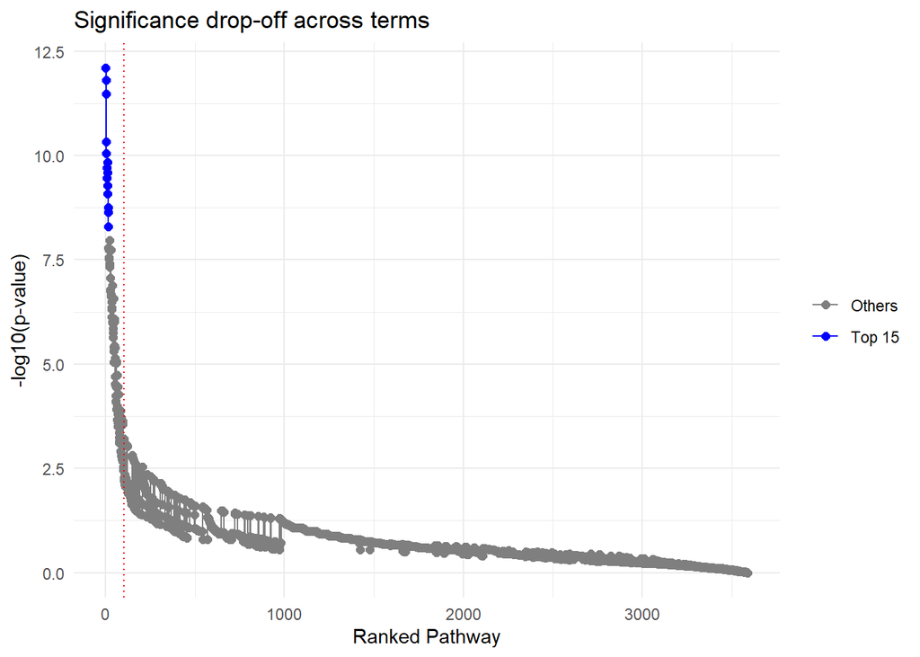

```r
ggplot(ora_plot_data, aes(x = rank, y = log10p, color = top15)) +
  geom_line() +
  geom_point(size = 2) +
  geom_vline(xintercept = fdr_cutoff_rank, linetype = "dotted", color = "red") +
  scale_color_manual(values = c("Top 15" = "blue", "Others" = "grey50")) +
  theme_minimal() +
  ggtitle("Significance drop-off across terms") +
  xlab("Ranked Pathway") +
  ylab("-log10(p-value)") +
  theme(legend.title = element_blank())
```

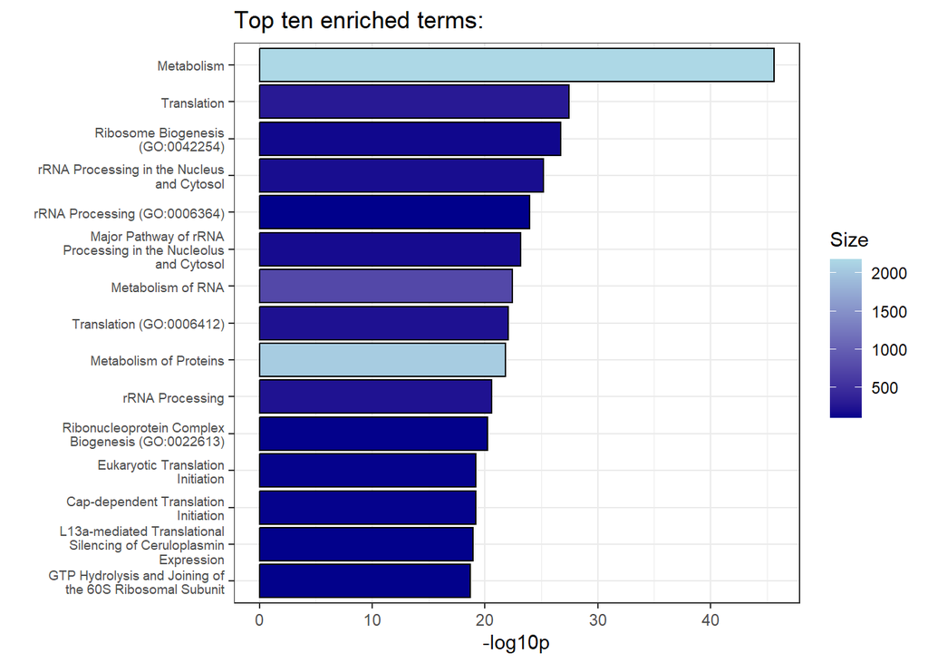

```r
ora_low %>%
  arrange(Adjusted.P.value, P.value) %>%
  head(15) %>%
  mutate(log10p = -log10(P.value)) %>%
  separate(Overlap,
           sep="/",
           into=c("Genes_found", "Size"),
           remove=F) %>%
  mutate(Size = as.numeric(Size),
         Genes = str_wrap(Genes, width = 10)) %>%
  ggplot(aes(y=reorder(Term, log10p))) +
  geom_col(aes(x=log10p, fill = Size),
           color='black') +
  scale_fill_gradient(
    low = "#00008b" ,   # Light blue
    high = "#add8e6"   # Dark blue
  ) +
  ylab('') + xlab('-log10p') + ggtitle("Top ten enriched terms: ") +
  scale_y_discrete(labels = function(x) str_wrap(x, width = 30)) +
  theme_bw() +
  theme(axis.text.y = element_text(size=7))
```

```r
ora_plot_data_low <- ora_low %>%
  arrange(Adjusted.P.value) %>%
  mutate(rank = row_number(),
         log10p = -log10(P.value),
         top15 = ifelse(rank <= 15, "Top 15", "Others"))
fdr_cutoff_rank_low <- min(ora_plot_data_low$rank[ora_plot_data_low$Adjusted.P.value > fdr_threshold], na.rm = TRUE)
```

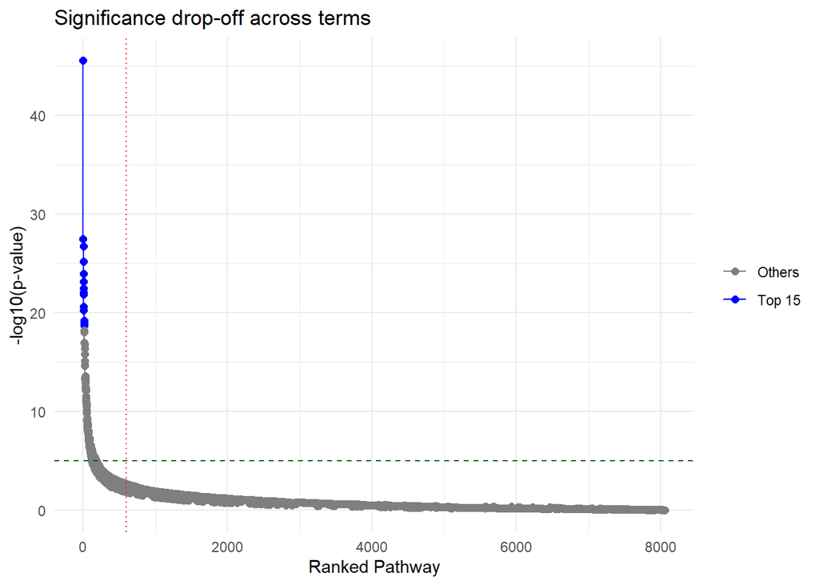

```r
ggplot(ora_plot_data_low, aes(x = rank, y = log10p, color = top15)) +
  geom_line() +
  geom_point(size = 2) +
  geom_vline(xintercept = fdr_cutoff_rank_low, linetype = "dotted", color = "red") +
  geom_hline(yintercept = 5, linetype = "dashed", color = "darkgreen") +
  scale_color_manual(values = c("Top 15" = "blue", "Others" = "grey50")) +
  theme_minimal() +
  ggtitle("Significance drop-off across terms") +
  xlab("Ranked Pathway") +
  ylab("-log10(p-value)") +
  theme(legend.title = element_blank())
```

ORA following metformin exposure reveals strong enrichment in pathways related to rRNA processing, ribosome biogenesis, translation, and RNA metabolism. These results align well with metformin’s established MoA, activation of AMPK and downstream inhibition of mTORC1 signaling, which collectively suppress global protein synthesis and ribosomal output. This shift reflects the drug’s energy-conserving effect, where cells prioritize maintenance over growth and proliferation.

More specifically, several enriched terms point to regulation of translation machinery. These include *GTP hydrolysis* and *joining of the 60S ribosomal subunit*, a crucial step in translation initiation, and *cap-dependent translation initiation*, which governs most eukaryotic mRNA translation under normal conditions. *Enrichment in eukaryotic translation initiation* and *a-mediated translational silencing of ceruloplasmin expression* further supports the idea that metformin exerts selective control over protein synthesis at multiple regulatory levels.

In parallel, the *enrichment of ribonucleoprotein complex biogenesis* and broader *RNA metabolic processes* suggests a coordinated suppression or remodeling of ribosome assembly and mRNA processing pathways. Together, these findings highlight metformin’s role in reshaping the translational and ribosomal landscape of the cell, reinforcing its effect as a metabolic stressor that promotes cellular adaptation through translational repression.

## 2.6 Upset plot

You may also want to visualize the top enriched terms for both compounds together.

**Exercise: Use `geom_tile()` to do this:**

```r
top_terms <- c((ora_high %>% head(15))$Term, (ora_low %>% head(15))$Term)
top_terms
```

```
##  [1] "Translation (GO:0006412)"
##  [2] "Macromolecule Biosynthetic Process (GO:0009059)"
##  [3] "Cytoplasmic Translation (GO:0002181)"
##  [4] "Gene Expression (GO:0010467)"
##  [5] "Proton Motive Force-Driven Mitochondrial ATP Synthesis (GO:0042776)"
##  [6] "Proton Motive Force-Driven ATP Synthesis (GO:0015986)"
##  [7] "Oxidative Phosphorylation (GO:0006119)"
##  [8] "Ribonucleoprotein Complex Biogenesis (GO:0022613)"
##  [9] "Protein Transport (GO:0015031)"
## [10] "Ribosomal Small Subunit Biogenesis (GO:0042274)"
## [11] "Protein Metabolic Process (GO:0019538)"
## [12] "ATP Biosynthetic Process (GO:0006754)"
## [13] "Ribosome Biogenesis (GO:0042254)"
## [14] "Regulation of Transcription by RNA Polymerase I (GO:0006356)"
## [15] "Chromatin Remodeling (GO:0006338)"
## [16] "Ribosome Biogenesis (GO:0042254)"
## [17] "rRNA Processing (GO:0006364)"
## [18] "Translation (GO:0006412)"
## [19] "Ribonucleoprotein Complex Biogenesis (GO:0022613)"
## [20] "rRNA Metabolic Process (GO:0016072)"
## [21] "Gene Expression (GO:0010467)"
## [22] "Cytoplasmic Translation (GO:0002181)"
## [23] "Macromolecule Biosynthetic Process (GO:0009059)"
## [24] "protein-RNA Complex Assembly (GO:0022618)"
## [25] "RNA Processing (GO:0006396)"
## [26] "Ribosomal Large Subunit Biogenesis (GO:0042273)"
## [27] "Ribosomal Small Subunit Biogenesis (GO:0042274)"
## [28] "Positive Regulation of Apoptotic Process (GO:0043065)"
## [29] "Regulation of Apoptotic Process (GO:0042981)"
## [30] "Steroid Metabolic Process (GO:0008202)"
```

Then we bind the results together, making a new variable specifying if the compound is high or low toxicity:

```r
ora_high$Toxicity <- "High"
ora_low$Toxicity <- "Low"

ora_both <- rbind(ora_high, ora_low)
ora_both
```

| Term | Overlap | P.value | Adjusted.P.value | Old.P.value | Old.Adjusted.P.value | Odds.Ratio | Combined.Score | Genes | Toxicity |
| --- | --- | --- | --- | --- | --- | --- | --- | --- | --- |
| Translation (GO:0006412) | 24/232 | 3.382393e-12 | 6.456988e-09 | 0 | 0 | 6.85991531 | 1.811871e+02 | RPL21;RPS8;VTA1;RPL23A;RPL8;EEF2;RPL9;MRPL57;GSPT1;MRPL21;DARS1;WARS1;RPS15;EEF1A1;RPS17;MRPS9;RPS29;MTG1;RPL36;RPS3;RPS20;RPS11;AURKAIP1;RPS12 | High |
| Macromolecule Biosynthetic Process (GO:0009059) | 20/189 | 1.488091e-10 | 1.420383e-07 | 0 | 0 | 6.96472944 | 1.576004e+02 | RPL21;RPS8;RPL23A;RPL8;EEF2;RPL9;GSPT1;DARS1;WARS1;RPS15;EEF1A1;RPS17;RPS29;RPL36;RPS3;RPS20;RPS11;EIF4G2;RPS12;TGM2 | High |
| Cytoplasmic Translation (GO:0002181) | 15/101 | 2.601472e-10 | 1.655403e-07 | 0 | 0 | 10.15521179 | 2.241232e+02 | RPL21;RPS8;VTA1;RPL23A;RPL8;RPL9;RPS15;RPS17;RPS29;EIF3I;RPL36;RPS3;RPS20;RPS11;RPS12 | High |
| Gene Expression (GO:0010467) | 25/381 | 1.826759e-08 | 8.718209e-06 | 0 | 0 | 4.15596781 | 7.405160e+01 | RPL8;RPL9;GSPT1;SMG5;RPS15;RPS17;RPL36;RPS3;RPS11;RBM5;RPS12;TGM2;RPL21;RPS8;TESC;RPL23A;DARS1;WARS1;THAP1;EEF1A1;DDX39A;RPS29;MPHOSPH10;RPS20;AURKAIP1 | High |
| Proton Motive Force-Driven Mitochondrial ATP Synthesis (GO:0042776) | 9/52 | 2.697828e-07 | 1.030031e-04 | 0 | 0 | 11.99877601 | 1.814893e+02 | ATP5PF;ATP5PD;NDUFA11;NDUFA3;ATP5PO;NDUFB1;NDUFC1;ATP5F1D;ATP5MF | High |
| Proton Motive Force-Driven ATP Synthesis (GO:0015986) | 9/59 | 8.271094e-07 | 2.613098e-04 | 0 | 0 | 10.31526316 | 1.444687e+02 | ATP5PF;ATP5PD;NDUFA11;NDUFA3;ATP5PO;NDUFB1;NDUFC1;ATP5F1D;ATP5MF | High |
| Oxidative Phosphorylation (GO:0006119) | 9/60 | 9.581814e-07 | 2.613098e-04 | 0 | 0 | 10.11248710 | 1.401412e+02 | ATP5PF;ATP5PD;NDUFA11;NDUFA3;ATP5PO;NDUFB1;NDUFC1;ATP5F1D;ATP5MF | High |
| Ribonucleoprotein Complex Biogenesis (GO:0022613) | 11/120 | 8.775821e-06 | 1.991549e-03 | 0 | 0 | 5.79978413 | 6.752985e+01 | RPS15;RCL1;RPS17;WDR36;RPS8;GTF3A;RRS1;NOL7;MPHOSPH10;RPS11;RPS12 | High |
| Protein Transport (GO:0015031) | 18/308 | 9.389177e-06 | 1.991549e-03 | 0 | 0 | 3.60838770 | 4.177053e+01 | TMED10;FGG;AFM;AP2A1;MCOLN1;STX10;EHD1;RAB32;RAB10;KRT18;CTTN;CANX;LAMP2;TOM1;RAB18;RAB17;APOB;YWHAH | High |
| Ribosomal Small Subunit Biogenesis (GO:0042274) | 9/85 | 1.816298e-05 | 3.467314e-03 | 0 | 0 | 6.77735457 | 7.398245e+01 | RPS15;RCL1;RPS17;WDR36;RPS8;NOL7;MPHOSPH10;RPS11;RPS12 | High |

[output cut: 9990 more lines]

Then, we can make the plot:

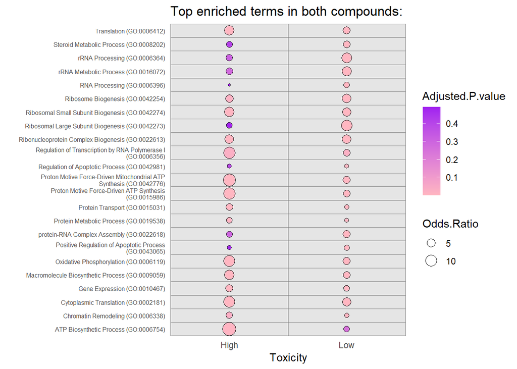

```r
ora_both %>%
  filter(Term %in% top_terms) %>%
  ggplot(aes(y=Term, x=Toxicity)) +
  geom_tile(color="grey50", fill="grey90", linewidth = 0.3) +
  geom_point(aes(fill=Adjusted.P.value, size=Odds.Ratio), shape=21, color='black') +
  ylab("") +
  scale_y_discrete(labels = function(x) str_wrap(x, width = 50),
                   expand=c(0,0)) +
  scale_x_discrete(expand=c(0,0)) +
  scale_fill_gradientn(colors = c('lightpink', 'purple')) +
  ggtitle('Top enriched terms in both compounds:') +
  theme_minimal() +
  theme(
    axis.text.y = element_text(size=6),
    panel.background = element_rect(fill='white', color='grey50'),
    panel.grid = element_blank()
  )
```

The dots represent enrichment of specific terms, where the size indicates the odds ratio (larger dots mean stronger associations), and color reflects the adjusted p-value (pink signifies more significant enrichment, while purple indicates less significance).

Additionally, the upregulation of *cytoplasmic translation* and *regulation of transcription by RNA polymerase I* indicates increased activity in protein synthesis and ribosomal gene expression. These pathways are typically associated with high metabolic activity and biosynthetic capacity. Their enrichment may reflect an adaptive cellular response aimed at maintaining proteostasis or could point to stress-induced remodeling of transcriptional and translational programs. Together, these findings suggest that theophylline impacts both mitochondrial energy production and core gene expression machinery, potentially reshaping hepatocyte function under pharmacological exposure.

For Metformin on the other hand, (smaller odds) the enrichment of pathways such as *ribosomal large subunit biosynthesis*, *rRNA processing*, and *rRNA metabolic processing* highlights a strong impact on protein synthesis. These processes are important for the assembly and function of ribosomes, which are essential for cellular growth and proliferation.

Metformin is well known to activate AMPK and inhibit mTORC1, a key regulator of ribosome biogenesis and translation. The observed enrichment may reflect a disruption or downregulation of these processes as part of a broader energy-conserving response. Suppression of ribosomal production and rRNA maturation aligns with metformin’s role in reducing anabolic activity under metabolic stress, redirecting resources away from growth-related functions toward cellular maintenance and survival. These findings reinforce the concept that metformin induces a transcriptional program consistent with reduced biosynthetic load and enhanced energy efficiency.

# 3 Session Info

```r
library(sessioninfo)
```